# Testing the Gap statistic under different levels of cluster overlap

SK

**Simulation study:** How does the Gap statistic behave under different levels of overlap between the clusters.

To run this vignette we need a few R-packages:

```r
require(cluster)
require(ggplot2)
require(patchwork)
```

## Data

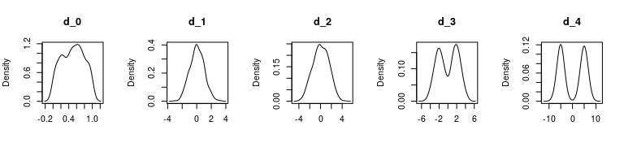

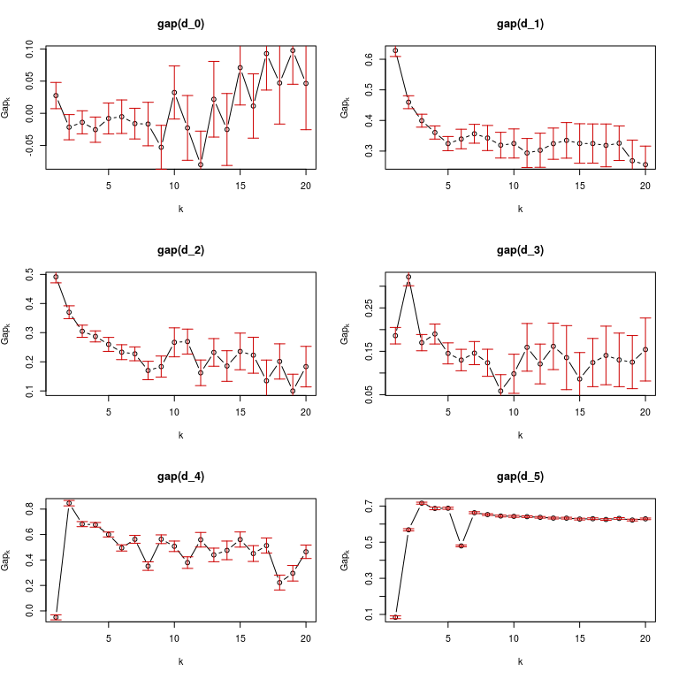

# Simulation of a “clumpy” data

## Case A (simple)

We have 30 cell subtypes. They belong to two tissues A and B (or general cell types). 70% of the cell subtypes belong to tissue A and 30% to B. From subtype $i$ we simulate $n_i~\sim U(50, 100)$ cells. Each cell has 100 features and 30% of them are selected to be tissue marker genes. If a given feature is a marker, then the mean gene expression of the subtype $\mu_{i\in A}~N(5, 1)$ or $\mu_{i\in B}~N(-5, 1)$. If a feature is not a marker gene ($\approx 70%$) then gene expression is drawn from $\mu_{i}\sim N(0, 5)$. Gene expression in a particular cell of subtype $i$ is then drawn from $N(\mu_i, 1)$.

We compute the Gap statistic with the resulting data.

```
FALSE Clustering k = 1,2,..., K.max (= 20): .. done
FALSE Bootstrapping, b = 1,2,..., B (= 100)  [one "." per sample]:
FALSE .................................................. 50
FALSE .................................................. 100
```

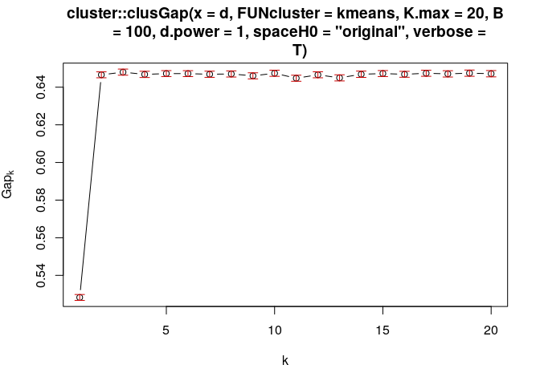

## Case B (more complex)

We have 30 cell subtypes. They belong to two tissues A and B (or general cell types). 70% of the cell subtypes belong to tissue A and 30% to B. From subtype $i$ we simulate $n_i~\sim U(50, 100)$ cells. Each cell has 100 features. We draw 100 values from $p\sim U(0, 1)$. If $0.2<p_j\leq0.5$ then feature $j$ is a tissue marker, and its mean gene expression is $\mu_{i\in A}~N(5, 1)$ or $\mu_{i\in B}~N(-5, 1)$. If $p_j\leq0.2$ then feature $j$ is subtype marker, and its mean gene expression is $\mu_{i} \pm N(5, 0.5)$. If $p_j>0.5$ $j$ is a noise feature $\mu_{i}\sim N(0, 5)$. Gene expression in a particular cell of subtype $i$ is then drawn from $N(\mu_i, 1)$.

We compute the Gap statistic with the resulting data.

**Strong subtype effect (structure within structure) leads to Gap statistics that keeps on increasing with increasing $k$**

```
FALSE Clustering k = 1,2,..., K.max (= 20): .. done
FALSE Bootstrapping, b = 1,2,..., B (= 50)  [one "." per sample]:
FALSE .................................................. 50
```

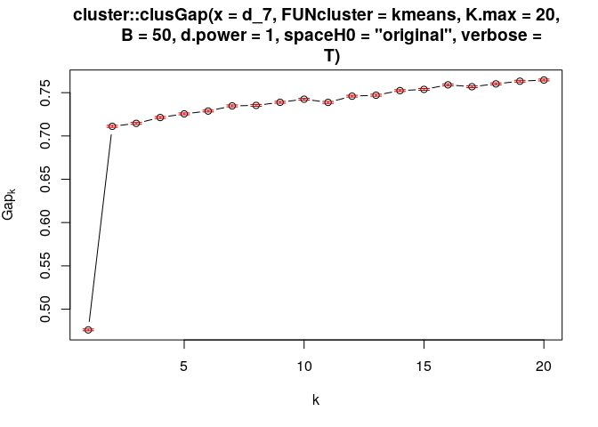